# STATS 503 Lab 3: KNN for Classification

Songkai Xue

February 5, 2021

## 1. Data Preprocessing

### 1.1. Loading Dataset

In this lab, we will perform KNN classification on the `FIFA Player 20` dataset from `Kaggle` (https://www.kaggle.com/stefanoleone992/fifa-20-complete-player-dataset). The provided datasets include the players data for the Career Mode from FIFA 15 to FIFA 20 (`"players_20.csv"`). The data, consisting of more than 100 variables, allow multiple comparison of the same players across the last 6 version of the videogame. We aim at predicting the `wage_eur` of a player using `international_reputation`, `skill_moves`, `shooting`, `passing`, `dribbling` and `defending`. To make it a classification problem, we create an indicator `wage_binary`to represent whether a player’s wage exceeding the population median.

```r
library(dplyr)
library(tidyr)
# library(corrplot)
library(ggplot2)

dat = read.csv("players_20.csv")
dat = dat %>% select("wage_eur", "international_reputation", "skill_moves", "shooting", "passing", "dribbling", "defending")
dat$wage_binary = factor(dat$wage_eur > median(dat$wage_eur))
levels(dat$wage_binary) = c("Low", "High")
```

```r
head(dat)
```

```
##   wage_eur international_reputation skill_moves shooting passing dribbling
## 1   565000                        5           4       92      92        96
## 2   405000                        5           5       93      82        89
## 3   290000                        5           5       85      87        95
## 4   125000                        3           1       NA      NA        NA
## 5   470000                        4           4       83      86        94
## 6   370000                        4           4       86      92        86
##   defending wage_binary
## 1        39        High
## 2        35        High
## 3        32        High
## 4        NA        High
## 5        35        High
## 6        61        High
```

### 1.2. Train-Test Split

We seperate training and test set.

```r
set.seed(1)
num = dim(dat)[1]
id.train = sample(seq(1, num), size = num * 0.7)
dat.train = dat[id.train, ]
dat.test = dat[-id.train, ]
```

### 1.3. Missing Data

Check missing rates and variable ranges.

```r
summary(dat.train)
```

```
##     wage_eur      international_reputation  skill_moves       shooting
##  Min.   :     0   Min.   :1.000            Min.   :1.000   Min.   :15.00
##  1st Qu.:  1000   1st Qu.:1.000            1st Qu.:2.000   1st Qu.:42.00
##  Median :  3000   Median :1.000            Median :2.000   Median :54.00
##  Mean   :  9422   Mean   :1.104            Mean   :2.369   Mean   :52.29
##  3rd Qu.:  8000   3rd Qu.:1.000            3rd Qu.:3.000   3rd Qu.:63.00
##  Max.   :370000   Max.   :5.000            Max.   :5.000   Max.   :91.00
##                                                            NA's   :1424
##     passing        dribbling      defending     wage_binary
##  Min.   :24.00   Min.   :23.0   Min.   :15.00   Low :7008
##  1st Qu.:51.00   1st Qu.:57.0   1st Qu.:37.00   High:5786
##  Median :58.00   Median :64.0   Median :56.00
##  Mean   :57.31   Mean   :62.6   Mean   :51.57
##  3rd Qu.:65.00   3rd Qu.:69.0   3rd Qu.:65.00
##  Max.   :92.00   Max.   :95.0   Max.   :90.00
##  NA's   :1424    NA's   :1424   NA's   :1424
```

```r
summary(dat.test)
```

```
##     wage_eur      international_reputation  skill_moves       shooting
##  Min.   :     0   Min.   :1.000            Min.   :1.000   Min.   :16.00
##  1st Qu.:  1000   1st Qu.:1.000            1st Qu.:2.000   1st Qu.:42.00
##  Median :  3000   Median :1.000            Median :2.000   Median :54.00
##  Mean   :  9538   Mean   :1.102            Mean   :2.366   Mean   :52.33
##  3rd Qu.:  8000   3rd Qu.:1.000            3rd Qu.:3.000   3rd Qu.:63.00
##  Max.   :565000   Max.   :5.000            Max.   :5.000   Max.   :93.00
##                                                            NA's   :612
##     passing        dribbling       defending     wage_binary
##  Min.   :24.00   Min.   :26.00   Min.   :15.00   Low :3000
##  1st Qu.:50.00   1st Qu.:57.00   1st Qu.:36.00   High:2484
##  Median :58.00   Median :64.00   Median :56.00
##  Mean   :57.05   Mean   :62.37   Mean   :51.52
##  3rd Qu.:64.00   3rd Qu.:69.00   3rd Qu.:65.00
##  Max.   :92.00   Max.   :96.00   Max.   :90.00
##  NA's   :612     NA's   :612     NA's   :612
```

We found missing values. As we have sufficient samples, we simply drop all the rows with at least one missing value.

```r
dat.train = dat.train[complete.cases(dat.train), ]
dat.test = dat.test[complete.cases(dat.test), ]
```

```r
summary(dat.train)
```

```
##     wage_eur      international_reputation  skill_moves      shooting
##  Min.   :     0   Min.   :1.000            Min.   :2.00   Min.   :15.00
##  1st Qu.:  1000   1st Qu.:1.000            1st Qu.:2.00   1st Qu.:42.00
##  Median :  3000   Median :1.000            Median :2.00   Median :54.00
##  Mean   :  9744   Mean   :1.105            Mean   :2.54   Mean   :52.29
##  3rd Qu.:  9000   3rd Qu.:1.000            3rd Qu.:3.00   3rd Qu.:63.00
##  Max.   :370000   Max.   :5.000            Max.   :5.00   Max.   :91.00
##     passing        dribbling      defending     wage_binary
##  Min.   :24.00   Min.   :23.0   Min.   :15.00   Low :6054
##  1st Qu.:51.00   1st Qu.:57.0   1st Qu.:37.00   High:5316
##  Median :58.00   Median :64.0   Median :56.00
##  Mean   :57.31   Mean   :62.6   Mean   :51.57
##  3rd Qu.:65.00   3rd Qu.:69.0   3rd Qu.:65.00
##  Max.   :92.00   Max.   :95.0   Max.   :90.00
```

```r
summary(dat.test)
```

```
##     wage_eur      international_reputation  skill_moves       shooting
##  Min.   :     0   Min.   :1.000            Min.   :2.000   Min.   :16.00
##  1st Qu.:  1000   1st Qu.:1.000            1st Qu.:2.000   1st Qu.:42.00
##  Median :  3000   Median :1.000            Median :2.000   Median :54.00
##  Mean   :  9954   Mean   :1.104            Mean   :2.538   Mean   :52.33
##  3rd Qu.:  9000   3rd Qu.:1.000            3rd Qu.:3.000   3rd Qu.:63.00
##  Max.   :565000   Max.   :5.000            Max.   :5.000   Max.   :93.00
##     passing        dribbling       defending     wage_binary
##  Min.   :24.00   Min.   :26.00   Min.   :15.00   Low :2586
##  1st Qu.:50.00   1st Qu.:57.00   1st Qu.:36.00   High:2286
##  Median :58.00   Median :64.00   Median :56.00
##  Mean   :57.05   Mean   :62.37   Mean   :51.52
##  3rd Qu.:64.00   3rd Qu.:69.00   3rd Qu.:65.00
##  Max.   :92.00   Max.   :96.00   Max.   :90.00
```

## 2. Exploratory Data Analysis (EDA)

### 2.1. Scatterplot Matrix

The `ggpairs()` function of the `GGally` package allows to build a great scatterplot matrix.

Scatterplots of each pair of numeric variable are drawn on the upper right part of the figure. Pearson correlation is displayed on the lower left. Variable distribution (given by kernel density estimation) is available on the diagonal.

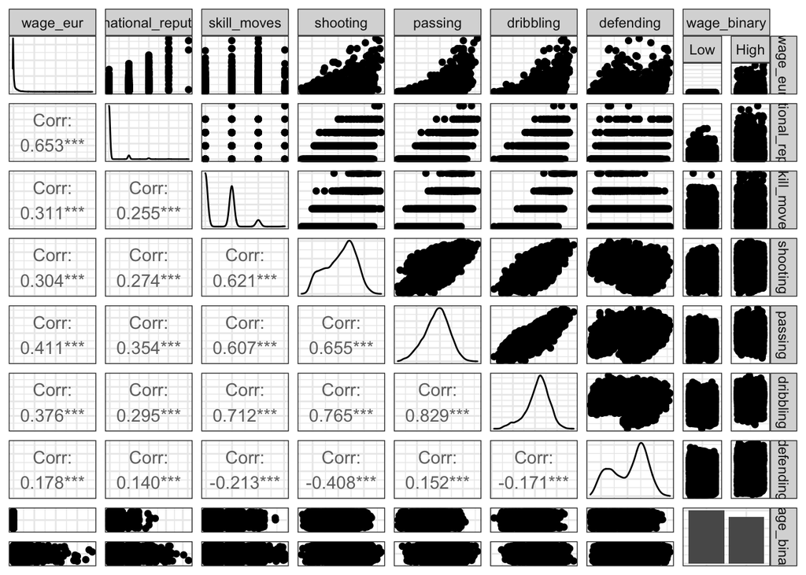

```r
library(GGally)
ggpairs(dat.train, axisLabels = 'none',
        upper = list(continuous = 'points', combo = 'dot'),
        lower = list(continuous = 'cor', combo = 'dot'),
        diag = list(continuous = 'densityDiag')) +
  theme_bw()
```

### 2.2. Boxplots

Converting between wide table and long table is a useful way to match various inputs of functions. We convert our table from `wide` to `long` to draw boxplots with subfigures using `ggplot2`.

```r
# Transform from wide table to long table
dat.explore = gather(dat.train, key = "Variable", value = "Value", -c("wage_binary", "wage_eur"))
head(dat.explore)
```

```
##   wage_eur wage_binary                 Variable Value
## 1     1000         Low international_reputation     1
## 2     7000        High international_reputation     1
## 3     1000         Low international_reputation     1
## 4     2000         Low international_reputation     1
## 5    18000        High international_reputation     1
## 6     4000        High international_reputation     1
```

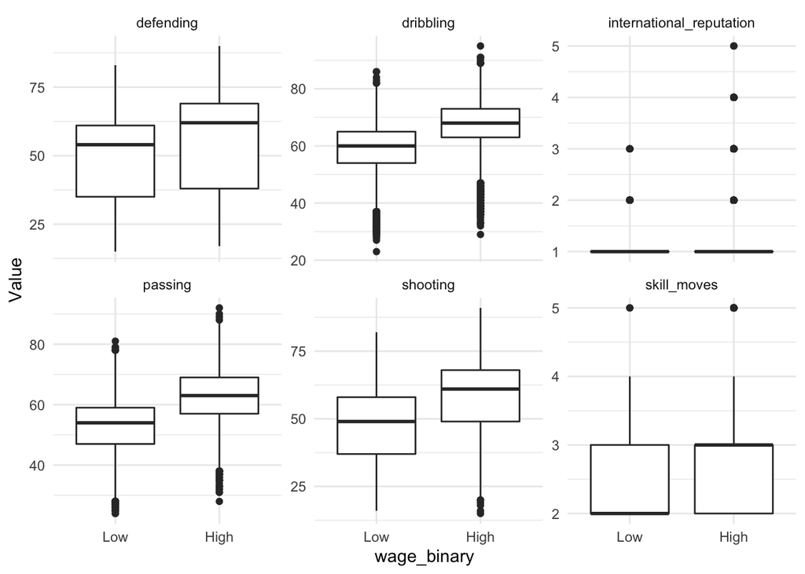

```r
ggplot(dat.explore) + geom_boxplot(aes(x = wage_binary, y = Value)) + facet_wrap(.~Variable, scales = "free_y") + theme_minimal()
```

As we can see, `dribbling` and `passing` seem to be more useful in predicting `wage_binary`. We now use KNN to test the performance.

## 3. KNN classification

```r
library(class)
```

We need to pull out the outcome variable and the design matrix for the training and test data.

```r
train_label = dat.train %>% .$wage_binary
train_x = dat.train %>% select("international_reputation", "skill_moves", "shooting", "passing", "dribbling", "defending")

test_label = dat.test %>% .$wage_binary
test_x = dat.test %>% select("international_reputation", "skill_moves", "shooting", "passing", "dribbling", "defending")
```

### 3.1. Data Standardization

As we can see in the data exploration, the variables have different ranges. It is **very important to scale both training and test data in the same way**. In other words, we need to use same mean and standard deviation to transform both training and test data. Those desired mean and standard deviation used for scaling should only come from the training data.

```r
mean_train = colMeans(train_x)
std_train = sqrt(diag(var(train_x)))
# training data
train_x = scale(train_x, center = mean_train, scale = std_train)
# test data
test_x = scale(test_x, center = mean_train, scale = std_train)
```

- The `center = ...` argument specifies the mean for scaling.
- The `scale = ...` arguments specifies the standard deviation used for scaling.
- With the additional arguments, the scale() function will perform
  $$x_{i}^{\operatorname{std}}=\frac{x_{i}-\text{mean}_{\text{train}}}{\text{std}_{\text{train}}}.$$

### 3.2. KNN with K = 1

Now the `knn()` function can be used to predict whether `wage_eur` is high or low.

The function requires four inputs:

- `train`: matrix or data frame of training set cases;
- `test`: matrix or data frame of test set cases;
- `cl`: factor of true classifications of training set, i.e. labels;
- `k`: number of neighbours considered.

```r
set.seed(1)
pred_train = knn(train_x,
               train_x,
               train_label,
               k = 1)

pred_test = knn(train_x,
               test_x,
               train_label,
               k = 1)
```

### 3.3. Confusion Matrix

The `table()` function can be used to produce a **confusion matrix** in order to determine how many observations were correctly or incorrectly classified.

```r
# Pull out the true responses for the test data
table(pred_train, train_label)
```

```
##           train_label
## pred_train  Low High
##       Low  6041   11
##       High   13 5305
```

```r
mean(pred_train == train_label)
```

```
## [1] 0.9978892
```

```r
table(pred_test, test_label)
```

```
##          test_label
## pred_test  Low High
##      Low  1991  666
##      High  595 1620
```

```r
mean(pred_test == test_label)
```

```
## [1] 0.7411741
```

We notice that KNN using `K = 1` does not give us 0 errors on training set. How to explain this?

The test results using `K = 1` are not very good compared to training errors, which means we have strong overfit.

### 3.4. KNN with Varing K

We further seek a best `K`.

```r
k_range = c(5, 10, 20, 25, 50, 200, 400)
train_error = c()
test_error = c()
for(i in 1:length(k_range)){
  pred_train <- knn(train_x,
               train_x,
               train_label,
               k = k_range[i])
  train_error[i] = mean(pred_train != train_label)
  pred_test = knn(train_x,
               test_x,
               train_label,
               k = k_range[i])
  test_error[i] = mean(pred_test != test_label)
}
```

For each iteration in the for loop, we fit a KNN model using the same dataset, but with different choice of `K` as `k_range[i]`. We compute the training and test error rate each round.

### 3.5. Plotting Training and Test Errors

Let’s create a plot for all those training and test error rates. Recall we want to plot error vs `1/K` as smaller `K` corresponds to more complex models.

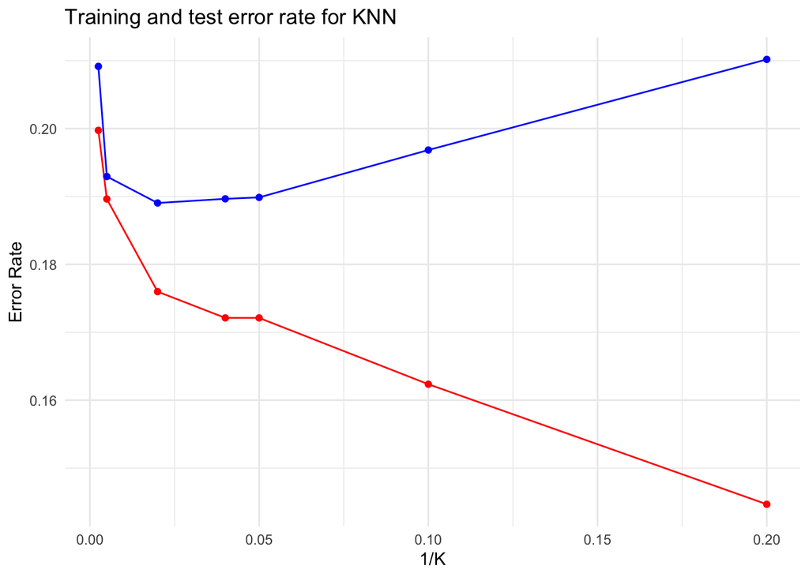

```r
errors = data.frame(train_error, test_error, k_range)
ggplot(errors, aes(x = 1/k_range)) +
  geom_line(aes(y = train_error), col = "red") + geom_point(aes(y = train_error), col = "red") +
  geom_line(aes(y = test_error), col = "blue") + geom_point(aes(y = test_error), col = "blue") +
  ylab("Error Rate") + xlab("1/K") + ggtitle("Training and test error rate for KNN") + theme_minimal()
```

Which `K` would you prefer, given the plot? Why?

## 4. Data Imputation

Handling missing values/data is an important part of the data preprocessing process. There are many reasons for missing data, for example, allowing null values, data loss, storage failure and refusal to fill in information.

```r
set.seed(1)
num = dim(dat)[1]
id.train = sample(seq(1, num), size = num * 0.7)
dat.train = dat[id.train, ]
dat.test = dat[-id.train, ]
```

```r
summary(dat.train)
```

```
##     wage_eur      international_reputation  skill_moves       shooting
##  Min.   :     0   Min.   :1.000            Min.   :1.000   Min.   :15.00
##  1st Qu.:  1000   1st Qu.:1.000            1st Qu.:2.000   1st Qu.:42.00
##  Median :  3000   Median :1.000            Median :2.000   Median :54.00
##  Mean   :  9422   Mean   :1.104            Mean   :2.369   Mean   :52.29
##  3rd Qu.:  8000   3rd Qu.:1.000            3rd Qu.:3.000   3rd Qu.:63.00
##  Max.   :370000   Max.   :5.000            Max.   :5.000   Max.   :91.00
##                                                            NA's   :1424
##     passing        dribbling      defending     wage_binary
##  Min.   :24.00   Min.   :23.0   Min.   :15.00   Low :7008
##  1st Qu.:51.00   1st Qu.:57.0   1st Qu.:37.00   High:5786
##  Median :58.00   Median :64.0   Median :56.00
##  Mean   :57.31   Mean   :62.6   Mean   :51.57
##  3rd Qu.:65.00   3rd Qu.:69.0   3rd Qu.:65.00
##  Max.   :92.00   Max.   :95.0   Max.   :90.00
##  NA's   :1424    NA's   :1424   NA's   :1424
```

### 4.1. Missing Data Pattern

The `mice` package provides a nice function `md.pattern()` to get a better understanding of the pattern of missing data.

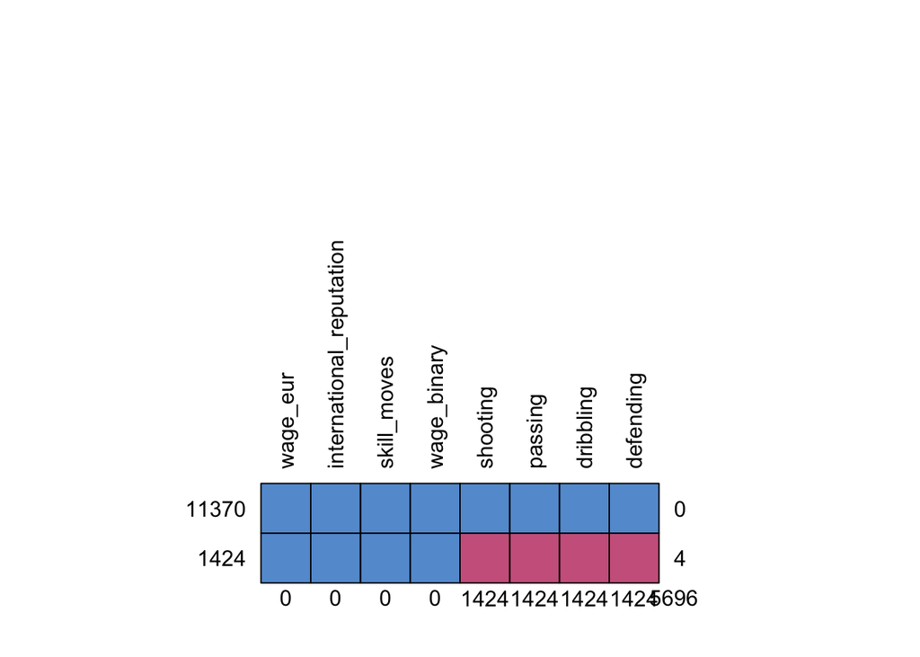

```
##       wage_eur international_reputation skill_moves wage_binary shooting
## 11370        1                        1           1           1        1
## 1424         1                        1           1           1        0
##              0                        0           0           0     1424
##       passing dribbling defending
## 11370       1         1         1    0
## 1424        0         0         0    4
##          1424      1424      1424 5696
```

```r
library(mice)
md.pattern(dat.train, plot = TRUE, rotate.names = TRUE)
```

How many observations in training set are complete?

### 4.2. Imputation Methods

**Imputation** is the process of replacing missing data with substituted values.

Two simple imputation methods are **mean imputation** and **median imputation**.

**(1) Mean imputation**

```r
# Copy training and test data
dat.train.mean = dat.train
dat.test.mean = dat.test

# Mean imputation, only column 4 - 7 have NA's
for (i in 4:7){
  dat.train.mean[is.na(dat.train.mean[,i]),i] = mean(dat.train.mean[!is.na(dat.train.mean[,i]),i])
  dat.test.mean[is.na(dat.test.mean[,i]),i] = mean(dat.test.mean[!is.na(dat.test.mean[,i]),i])
}
```

```r
summary(dat.train.mean)
```

```
##     wage_eur      international_reputation  skill_moves       shooting
##  Min.   :     0   Min.   :1.000            Min.   :1.000   Min.   :15.00
##  1st Qu.:  1000   1st Qu.:1.000            1st Qu.:2.000   1st Qu.:44.00
##  Median :  3000   Median :1.000            Median :2.000   Median :52.29
##  Mean   :  9422   Mean   :1.104            Mean   :2.369   Mean   :52.29
##  3rd Qu.:  8000   3rd Qu.:1.000            3rd Qu.:3.000   3rd Qu.:62.00
##  Max.   :370000   Max.   :5.000            Max.   :5.000   Max.   :91.00
##     passing        dribbling      defending     wage_binary
##  Min.   :24.00   Min.   :23.0   Min.   :15.00   Low :7008
##  1st Qu.:52.00   1st Qu.:58.0   1st Qu.:39.00   High:5786
##  Median :57.31   Median :62.6   Median :52.00
##  Mean   :57.31   Mean   :62.6   Mean   :51.57
##  3rd Qu.:64.00   3rd Qu.:69.0   3rd Qu.:64.00
##  Max.   :92.00   Max.   :95.0   Max.   :90.00
```

Which summary value remains the same after mean imputation?

**(2) Median imputation**

```r
# Copy training and test data
dat.train.med = dat.train
dat.test.med = dat.test

# Median imputation, only column 4 - 7 have NA's
for (i in 4:7){
  dat.train.med[is.na(dat.train.med[,i]),i] = median(dat.train.med[!is.na(dat.train.med[,i]),i])
  dat.test.med[is.na(dat.test.med[,i]),i] = median(dat.test.med[!is.na(dat.test.med[,i]),i])
}
```

```r
summary(dat.train.med)
```

```
##     wage_eur      international_reputation  skill_moves       shooting
##  Min.   :     0   Min.   :1.000            Min.   :1.000   Min.   :15.00
##  1st Qu.:  1000   1st Qu.:1.000            1st Qu.:2.000   1st Qu.:44.00
##  Median :  3000   Median :1.000            Median :2.000   Median :54.00
##  Mean   :  9422   Mean   :1.104            Mean   :2.369   Mean   :52.48
##  3rd Qu.:  8000   3rd Qu.:1.000            3rd Qu.:3.000   3rd Qu.:62.00
##  Max.   :370000   Max.   :5.000            Max.   :5.000   Max.   :91.00
##     passing        dribbling       defending     wage_binary
##  Min.   :24.00   Min.   :23.00   Min.   :15.00   Low :7008
##  1st Qu.:52.00   1st Qu.:58.00   1st Qu.:39.00   High:5786
##  Median :58.00   Median :64.00   Median :56.00
##  Mean   :57.39   Mean   :62.76   Mean   :52.06
##  3rd Qu.:64.00   3rd Qu.:69.00   3rd Qu.:64.00
##  Max.   :92.00   Max.   :95.00   Max.   :90.00
```

How does the variance of the predictors change after median imputation?

The `mice` package provides various imputation methods.

```r
methods(mice)
```

```
##  [1] mice.impute.2l.bin       mice.impute.2l.lmer      mice.impute.2l.norm
##  [4] mice.impute.2l.pan       mice.impute.2lonly.mean  mice.impute.2lonly.norm
##  [7] mice.impute.2lonly.pmm   mice.impute.cart         mice.impute.jomoImpute
## [10] mice.impute.lda          mice.impute.logreg       mice.impute.logreg.boot
## [13] mice.impute.mean         mice.impute.midastouch   mice.impute.mnar.logreg
## [16] mice.impute.mnar.norm    mice.impute.norm         mice.impute.norm.boot
## [19] mice.impute.norm.nob     mice.impute.norm.predict mice.impute.panImpute
## [22] mice.impute.passive      mice.impute.pmm          mice.impute.polr
## [25] mice.impute.polyreg      mice.impute.quadratic    mice.impute.rf
## [28] mice.impute.ri           mice.impute.sample       mice.mids
## [31] mice.theme
## see '?methods' for accessing help and source code
```

**(3) Predictive mean matching**

We consider imputation by predictive mean matching (PMM), proposed by Donald B. Rubin and Roderick J.A. Little. The implementation details of PMM can be found at https://cran.r-project.org/web/packages/mice/mice.pdf, page 115.

The function `mice()`, multivariate imputation by chained equations, creates multiple imputations for multivariate missing data.

```r
dat.train.temp = mice(dat.train, m=1, maxit=50, meth='pmm', seed=2021)
dat.test.temp = mice(dat.test, m=1, maxit=50, meth='pmm', seed=2021)
```

The function requires five inputs:

- `data`: the data frame for imputation;
- `m`: the number of imputed datasets;
- `maxit`: the number of iterations.
- `meth`: the imputation method;
- `seed`: an integer for setting the random number generator.

Now we can get back the completed dataset by using the `complete()` function.

```r
dat.train.pmm = complete(dat.train.temp, 1)
dat.test.pmm = complete(dat.test.temp, 1)
```

```r
summary(dat.train.pmm)
```

```
##     wage_eur      international_reputation  skill_moves       shooting
##  Min.   :     0   Min.   :1.000            Min.   :1.000   Min.   :15.00
##  1st Qu.:  1000   1st Qu.:1.000            1st Qu.:2.000   1st Qu.:37.00
##  Median :  3000   Median :1.000            Median :2.000   Median :52.00
##  Mean   :  9422   Mean   :1.104            Mean   :2.369   Mean   :49.86
##  3rd Qu.:  8000   3rd Qu.:1.000            3rd Qu.:3.000   3rd Qu.:62.00
##  Max.   :370000   Max.   :5.000            Max.   :5.000   Max.   :91.00
##     passing        dribbling       defending     wage_binary
##  Min.   :24.00   Min.   :23.00   Min.   :15.00   Low :7008
##  1st Qu.:48.00   1st Qu.:54.00   1st Qu.:38.00   High:5786
##  Median :57.00   Median :63.00   Median :57.00
##  Mean   :55.41   Mean   :60.25   Mean   :52.82
##  3rd Qu.:64.00   3rd Qu.:69.00   3rd Qu.:66.00
##  Max.   :92.00   Max.   :95.00   Max.   :90.00
```

```r
dim(dat.train.pmm)
```

```
## [1] 12794     8
```

```r
dim(dat.train)
```

```
## [1] 12794     8
```

### 4.3. Fitting KNN on Imputed Data

We fit KNN again on imputed data.

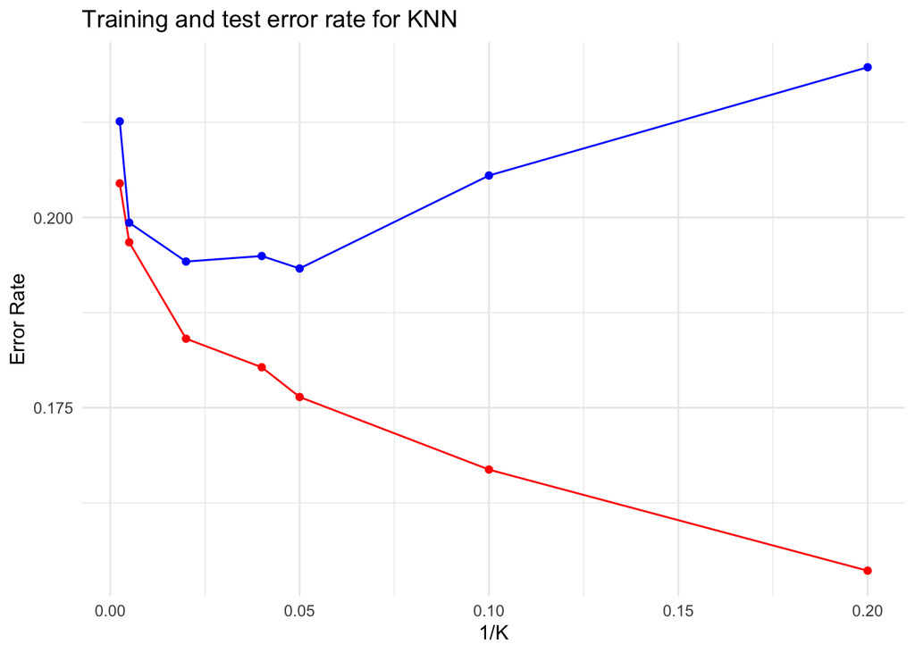

```r
# (1) Pulling out labels and design matrix
train_label = dat.train.pmm %>% .$wage_binary
train_x = dat.train.pmm %>% select("international_reputation", "skill_moves", "shooting", "passing", "dribbling", "defending")

test_label = dat.test.pmm %>% .$wage_binary
test_x = dat.test.pmm %>% select("international_reputation", "skill_moves", "shooting", "passing", "dribbling", "defending")

# (2) Standardization
mean_train = colMeans(train_x)
std_train = sqrt(diag(var(train_x)))
# training data
train_x = scale(train_x, center = mean_train, scale = std_train)
# test data
test_x = scale(test_x, center = mean_train, scale = std_train)

# (3) KNN with varing K
k_range = c(5, 10, 20, 25, 50, 200, 400)
train_error = c()
test_error = c()
for(i in 1:length(k_range)){
  pred_train <- knn(train_x,
               train_x,
               train_label,
               k = k_range[i])
  train_error[i] = mean(pred_train != train_label)
  pred_test = knn(train_x,
               test_x,
               train_label,
               k = k_range[i])
  test_error[i] = mean(pred_test != test_label)
}

# (4) Plotting error rate curves
errors = data.frame(train_error, test_error, k_range)
ggplot(errors, aes(x = 1/k_range)) +
  geom_line(aes(y = train_error), col = "red") + geom_point(aes(y = train_error), col = "red") +
  geom_line(aes(y = test_error), col = "blue") + geom_point(aes(y = test_error), col = "blue") +
  ylab("Error Rate") + xlab("1/K") + ggtitle("Training and test error rate for KNN") + theme_minimal()
```

The test error from dropping rows with missing data (section 3) can be viewed as a benchmark when comparing to imputation method.

Can we impute missing outcomes in the training set? **Nope.** If the outcome variable for an observation is missing, we will have to remove that observation.